# Forecasting Daily Gold Prices Using GARCH and ARIMA Models

STATS 531 Midterm Project

Feburary 21, 2025

# Introduction

Gold prices are influenced by various economic factors, including inflation, geopolitical events, and currency fluctuations, making accurate forecasting crucial for investors and policymakers. Time series models such as the **Autoregressive Integrated Moving Average (ARIMA)** and **Generalized Autoregressive Conditional Heteroskedasticity (GARCH)** are widely used for financial forecasting due to their ability to capture trend, seasonality, and volatility in price movements.

### Contextualizing This Project Within Past 531 Projects

From the past midterm projects and peer reviews, such as those referenced, we gain valuable insights into how ARIMA and GARCH models have been applied to different datasets and forecasting tasks. Our work builds on these foundations but differentiates itself by focusing specifically on gold price forecasting while comparing ARIMA and GARCH in terms of both price prediction and volatility modeling. We have also learned the importance of evaluating residual diagnostics, ensuring that model assumptions hold before forecasting. Many projects have also emphasized the need for context-aware forecasting, recognizing that external events (e.g., geopolitical factors) can significantly impact financial time series. Reviewing multiple past projects as a team has helped us refine our methodology and ensure that our conclusions are robust and well-grounded.

# Data Preprocess

[output not shown]

```
##         Date Price  Open  High   Low Volume  Chg.
## 1 2024-11-06 77030 78300 78570 77030      0 -1.86
## 2 2024-11-05 78490 78224 78670 78160      0  0.11
## 3 2024-11-04 78401 78498 78642 78237      0 -0.54
## 4 2024-11-01 78829 78650 78887 78550      0  0.64
## 5 2024-10-31 78326 79264 79999 77803     90 -1.17
## 6 2024-10-30 79257 79119 79375 78888    130  0.50
```

# EDA

## 1. Summary Statistics

```
##       Date                Price            Open            High
##  Min.   :2022-01-03   Min.   :47471   Min.   :47400   Min.   :47523
##  1st Qu.:2022-09-19   1st Qu.:51642   1st Qu.:51675   1st Qu.:51922
##  Median :2023-06-05   Median :58989   Median :58916   Median :59166
##  Mean   :2023-06-05   Mean   :59441   Mean   :59437   Mean   :59737
##  3rd Qu.:2024-02-20   3rd Qu.:62868   3rd Qu.:63040   3rd Qu.:63263
##  Max.   :2024-11-06   Max.   :79257   Max.   :79264   Max.   :79999
##       Low            Volume           Chg.
##  Min.   :47300   Min.   :    0   Min.   :-5.50000
##  1st Qu.:51394   1st Qu.: 4990   1st Qu.:-0.27000
##  Median :58694   Median : 9045   Median : 0.08000
##  Mean   :59156   Mean   : 9120   Mean   : 0.06749
##  3rd Qu.:62434   3rd Qu.:12795   3rd Qu.: 0.43250
##  Max.   :78888   Max.   :51930   Max.   : 2.97000
```

The gold price dataset spans from **January 3, 2022, to November 6, 2024**. The price ranges between **47,471 and 79,257**, with a mean of **59,441**, indicating a general increase over time. The **“Chg.” (percentage change)** variable shows fluctuations from **-5.5% to 2.97%**, suggesting volatility in gold prices.

## 2. Histogram and Density Plot

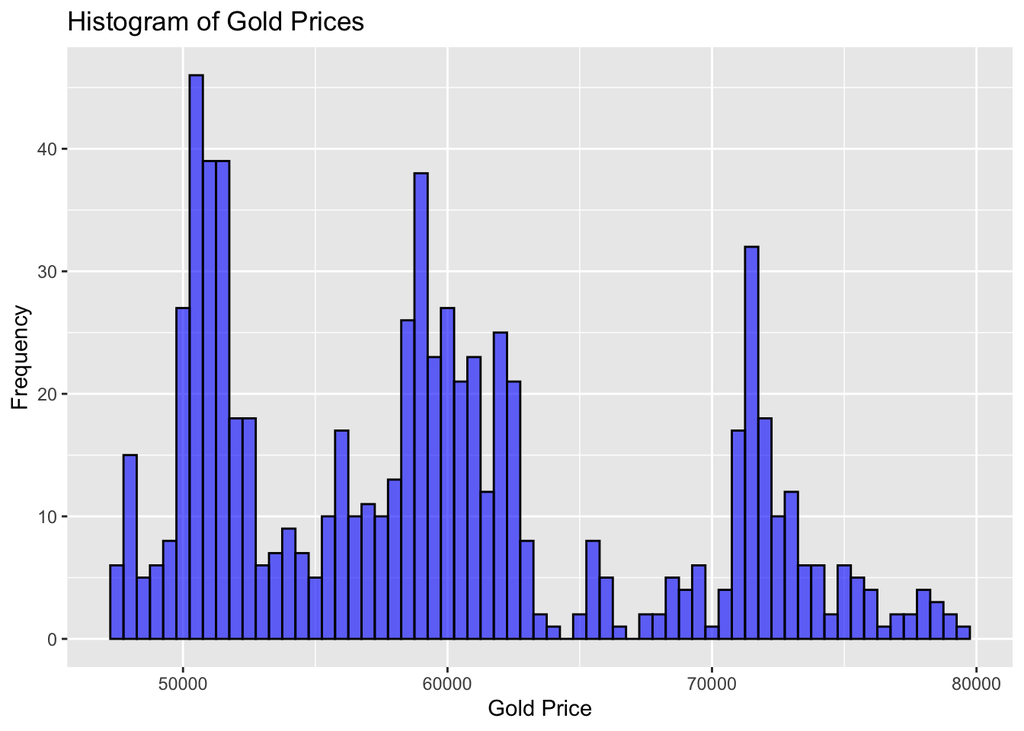

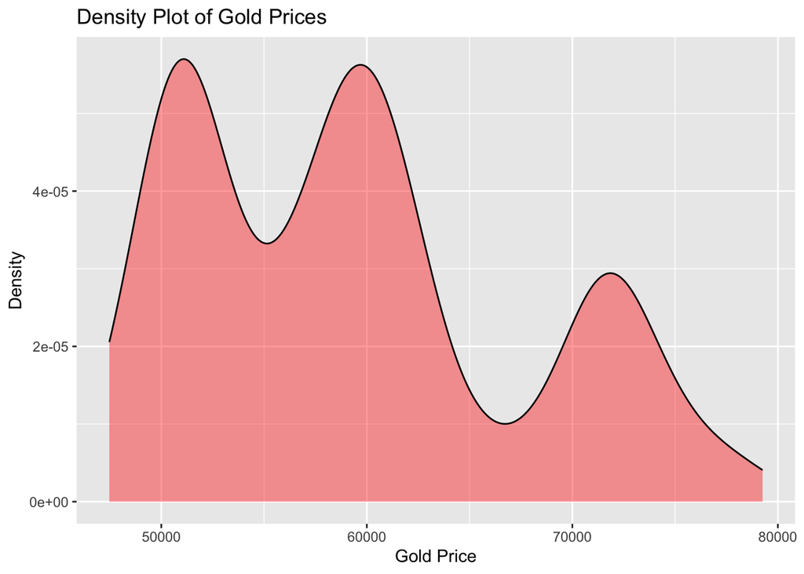

The histogram shows a **multi-modal distribution**, indicating that gold prices have shifted significantly over different periods. The density plot confirms the presence of **multiple peaks**, reinforcing the idea that gold prices have followed different trends over time. There are several peaks in both plots, which potentially correspond to different market regimes or events affecting gold prices.

## 3. Seasonal and Trend Decomposition (STL)

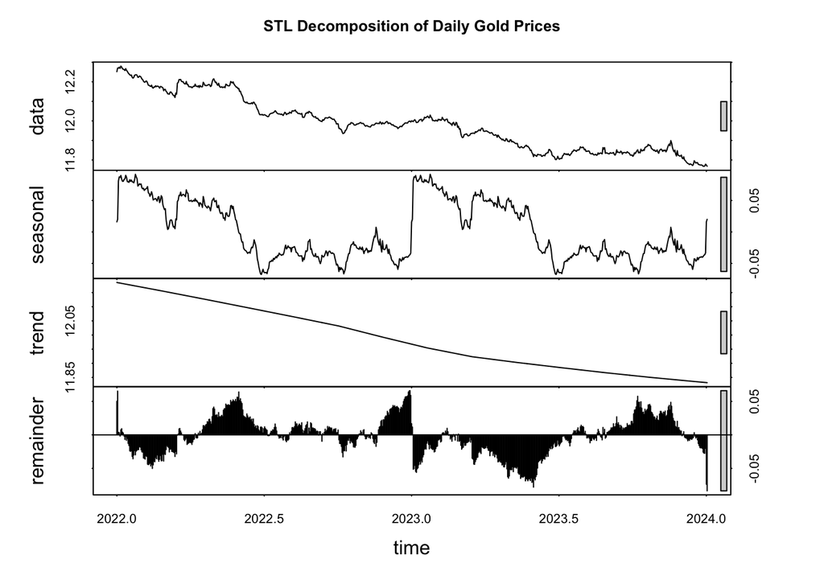

# Model Selection: ARIMA

### Model Formulation of ARIMA(p, d, q)

$$ARIMA(p, d, q)$$

where:

- $p$ is the number of **autoregressive (AR)** terms.
- $d$ is the degree of **differencing** required to make the series stationary.
- $q$ is the number of **moving average (MA)** terms.

The general form of the **ARIMA model** can be written as:

$$\phi(B) (1 - B)^d Y_t = \theta(B)
\epsilon_t$$

where:

- $B$ is the **backward shift operator** such that $B Y_t = Y_{t-1}$.
- $\phi(B) = 1 - \phi_1 B - \phi_2 B^2 - \dots - \phi_p B^p$ represents the **AR polynomial**.
- $(1 - B)^d$ represents the **differencing operation**.
- $\theta(B) = 1 + \theta_1 B + \theta_2 B^2 + \dots + \theta_q B^q$ represents the **MA polynomial**.
- $\epsilon_t$ is a **white noise process** with $E[\epsilon_t] = 0$ and $Var(\epsilon_t) = \sigma^2$.

### Model Assumptions

For the ARIMA model to be valid, the following **assumptions** must hold:

1. The time series should be **stationary** (achieved via differencing if needed).
2. The residuals $\epsilon_t$ should be **independent and identically distributed (i.i.d.)**.
3. The model parameters $\phi$ and $\theta$ should satisfy the **invertibility and stationarity conditions**.

### AIC Table

AIC Scores for Different ARIMA Models

|  | MA0 | MA1 | MA2 | MA3 | MA4 | MA5 | MA6 | MA7 | MA8 |
| --- | --- | --- | --- | --- | --- | --- | --- | --- | --- |
| AR0 | -4762.212 | -4761.320 | -4763.660 | -4761.816 | -4765.165 | -4765.109 | -4767.535 | -4766.774 | -4765.178 |
| AR1 | -4761.506 | -4761.831 | -4763.674 | -4761.731 | -4763.780 | -4764.636 | -4766.407 | -4765.091 | -4763.238 |
| AR2 | -4764.166 | -4763.588 | -4761.616 | -4759.940 | -4767.425 | -4777.609 | -4777.449 | -4775.620 | -4774.576 |
| AR3 | -4762.442 | -4761.588 | -4759.774 | -4763.274 | -4778.314 | -4776.880 | -4773.623 | -4763.623 | -4760.912 |
| AR4 | -4763.551 | -4762.007 | -4766.218 | -4765.059 | -4769.059 | -4774.545 | -4762.380 | -4773.257 | -4771.425 |
| AR5 | -4763.224 | -4762.402 | -4777.117 | -4775.940 | -4777.607 | -4776.061 | -4774.578 | -4771.916 | -4771.264 |
| AR6 | -4765.581 | -4765.274 | -4764.735 | -4764.483 | -4774.362 | -4775.047 | -4773.478 | -4770.071 | -4769.444 |
| AR7 | -4766.439 | -4764.736 | -4764.567 | -4763.696 | -4772.750 | -4771.772 | -4771.036 | -4772.522 | -4773.622 |
| AR8 | -4764.950 | -4762.951 | -4766.844 | -4761.731 | -4771.419 | -4770.967 | -4769.416 | -4771.888 | -4764.379 |

The Akaike Information Criterion (AIC) is used to compare models, with lower values indicating a better fit while balancing model complexity. **ARIMA(3,1,4)** should be selected as the final model since it has the relative low AIC, indicating the best balance of goodness-of-fit and complexity.

```
## Series: subset_data$Price
## ARIMA(3,1,4)
##
## Coefficients:
##          ar1      ar2     ar3      ma1     ma2      ma3     ma4
##       0.0506  -0.6749  0.4838  -0.0896  0.7924  -0.5276  0.1580
## s.e.  0.1657   0.0867  0.1547   0.1652  0.0910   0.1581  0.0427
##
## sigma^2 = 5.358e-05:  log likelihood = 2397.16
## AIC=-4778.31   AICc=-4778.1   BIC=-4742.09
##
## Training set error measures:
##                         ME        RMSE         MAE         MPE     MAPE
## Training set -0.0004886889 0.007276822 0.005185264 -0.00410068 0.043318
##                   MASE         ACF1
## Training set 0.9926981 5.814714e-05
```

### Wilks’ Likelihood Ratio Test for ARIMA(3,1,4) Model

We perform a Likelihood Ratio Test to compare the ARIMA(3, 1, 4) with an ARIMA(0,1,0) model to evaluates whether the additional parameters in the full model significantly improve the fit.

```
## Chi square statistic:  30.10155
```

```
## p value:  4.100041e-08
```

The chi-square statistic = 30.10 and p-value = 4.1e-08, which is highly significant (p < 0.05).

This strongly rejects the null hypothesis, indicating that the full ARIMA model provides a significantly better fit than the simple random walk model.Therefore, the ARIMA model captures meaningful patterns in the data and is preferable for forecasting gold prices.

# Model Selection: GARCH

## Model Assumptions

Garch Model(Generalized Autoregressive Conditional Heteroskedasticity) is commonly used in financial time series modeling. For a log-return time series $r_t$, $a_t = r_t - \mu_t$ is the innovation sequence, where $\mu_t$ is the mean value. {a_t} fits GARCH(m,s) model, if $a_t$ satisfies:

$$\begin{align}
a_t & = \sigma_t\epsilon_t \\
\sigma_t^2 & = \alpha_0 + \sum_{i = 1}^{m}\alpha_i a_{t-i}^2 +
\sum_{j = 1}^s \beta_j \sigma_{t-j}^2
\end{align}$$

$\epsilon_t \quad i.i.d. N(0,1)$ We choose ARIMA(3,1,4) as the mean model. Since GARCH(1,1) is most used among recent studies, we directly use residuals of ARIMA(3,1,4) to fit GARCH(1,1) model.

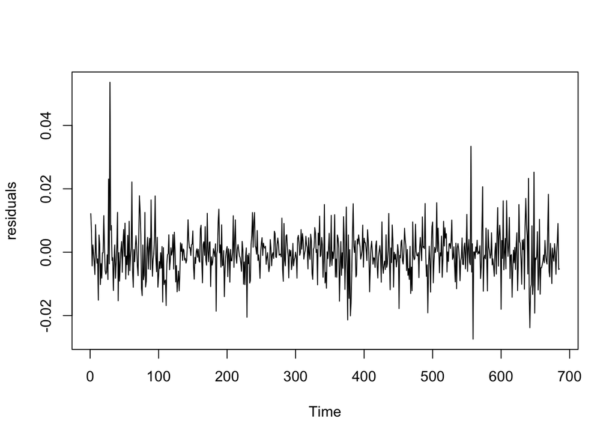

```
##
## Title:
##  GARCH Modelling
##
## Call:
##  garchFit(formula = ~1 + garch(1, 1), data = residuals, trace = FALSE)
##
## Mean and Variance Equation:
##  data ~ 1 + garch(1, 1)
## <environment: 0x1315f6ea8>
##  [data = residuals]
##
## Conditional Distribution:
##  norm
##
## Coefficient(s):
##          mu        omega       alpha1        beta1
## -3.0899e-04   6.1728e-06   9.7028e-02   7.8807e-01
##
## Std. Errors:
##  based on Hessian
##
## Error Analysis:
##          Estimate  Std. Error  t value Pr(>|t|)
## mu     -3.090e-04   2.611e-04   -1.184  0.23660
## omega   6.173e-06   3.064e-06    2.014  0.04397 *
## alpha1  9.703e-02   2.998e-02    3.236  0.00121 **
## beta1   7.881e-01   7.721e-02   10.207  < 2e-16 ***
## ---
## Signif. codes:  0 '***' 0.001 '**' 0.01 '*' 0.05 '.' 0.1 ' ' 1
##
## Log Likelihood:
##  2420.109    normalized:  3.533005
##
## Description:
##  Tue Feb 18 13:34:22 2025 by user:
##
##
## Standardised Residuals Tests:
##                                   Statistic      p-Value
##  Jarque-Bera Test   R    Chi^2  378.3071329 0.000000e+00
##  Shapiro-Wilk Test  R    W        0.9611787 1.742846e-12
##  Ljung-Box Test     R    Q(10)    5.4567219 8.586587e-01
##  Ljung-Box Test     R    Q(15)   16.0624649 3.779124e-01
##  Ljung-Box Test     R    Q(20)   18.9343708 5.260956e-01
##  Ljung-Box Test     R^2  Q(10)    8.9527293 5.365956e-01
##  Ljung-Box Test     R^2  Q(15)   10.1949243 8.073027e-01
##  Ljung-Box Test     R^2  Q(20)   22.5137383 3.132965e-01
##  LM Arch Test       R    TR^2     9.5925749 6.516551e-01
##
## Information Criterion Statistics:
##       AIC       BIC       SIC      HQIC
## -7.054332 -7.027883 -7.054400 -7.044097
```

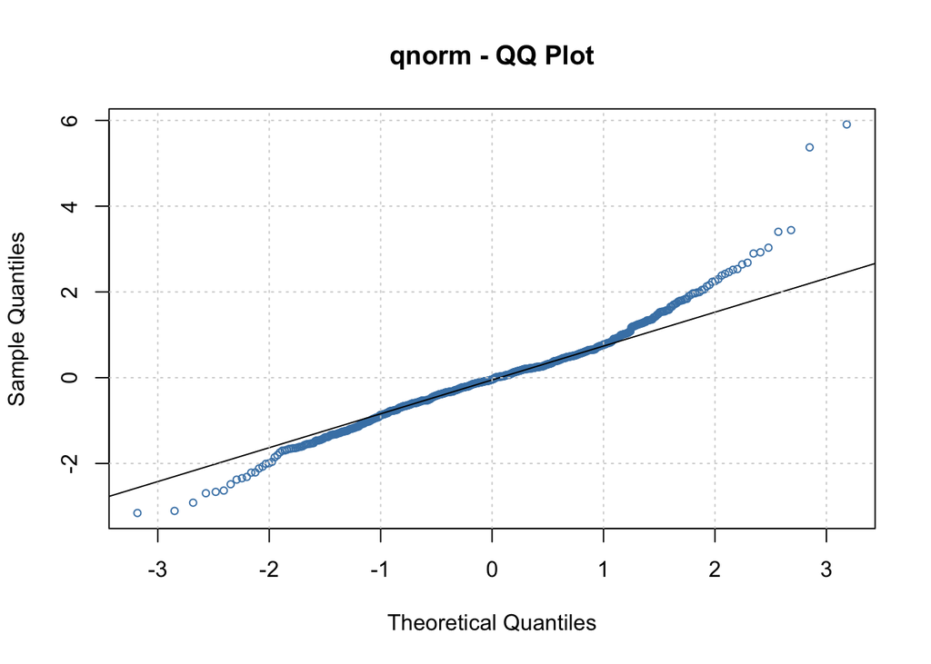

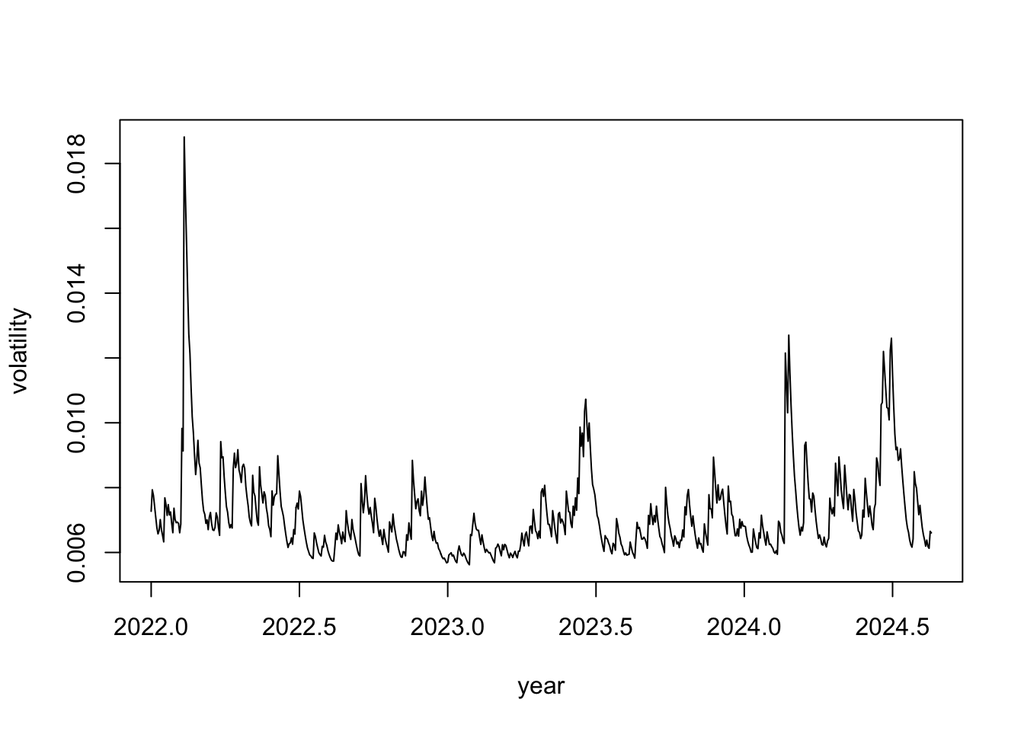

At the same time, by observing the QQ plot, we can see that the standardized residuals do not follow a normal distribution. Therefore, we attempt to fit a conditionally t-distribution and a conditionally biased t-distribution.

```
##
## Title:
##  GARCH Modelling
##
## Call:
##  garchFit(formula = ~1 + garch(1, 1), data = residuals, cond.dist = "std",
##     trace = FALSE)
##
## Mean and Variance Equation:
##  data ~ 1 + garch(1, 1)
## <environment: 0x132a7dd28>
##  [data = residuals]
##
## Conditional Distribution:
##  std
##
## Coefficient(s):
##          mu        omega       alpha1        beta1        shape
## -5.7393e-04   2.5948e-06   4.5757e-02   9.0788e-01   4.1797e+00
##
## Std. Errors:
##  based on Hessian
##
## Error Analysis:
##          Estimate  Std. Error  t value Pr(>|t|)
## mu     -5.739e-04   2.301e-04   -2.495   0.0126 *
## omega   2.595e-06   2.767e-06    0.938   0.3484
## alpha1  4.576e-02   3.245e-02    1.410   0.1585
## beta1   9.079e-01   7.696e-02   11.796  < 2e-16 ***
## shape   4.180e+00   7.311e-01    5.717 1.08e-08 ***
## ---
## Signif. codes:  0 '***' 0.001 '**' 0.01 '*' 0.05 '.' 0.1 ' ' 1
##
## Log Likelihood:
##  2455.286    normalized:  3.584359
##
## Description:
##  Tue Feb 18 13:34:22 2025 by user:
##
##
## Standardised Residuals Tests:
##                                   Statistic      p-Value
##  Jarque-Bera Test   R    Chi^2  582.8822046 0.000000e+00
##  Shapiro-Wilk Test  R    W        0.9563147 2.172970e-13
##  Ljung-Box Test     R    Q(10)    4.8319289 9.021187e-01
##  Ljung-Box Test     R    Q(15)   14.7146582 4.721595e-01
##  Ljung-Box Test     R    Q(20)   17.2141448 6.390277e-01
##  Ljung-Box Test     R^2  Q(10)   10.6120592 3.885294e-01
##  Ljung-Box Test     R^2  Q(15)   11.9094799 6.858674e-01
##  Ljung-Box Test     R^2  Q(20)   19.2866354 5.032707e-01
##  LM Arch Test       R    TR^2    11.7727518 4.640986e-01
##
## Information Criterion Statistics:
##       AIC       BIC       SIC      HQIC
## -7.154120 -7.121059 -7.154226 -7.141327
```

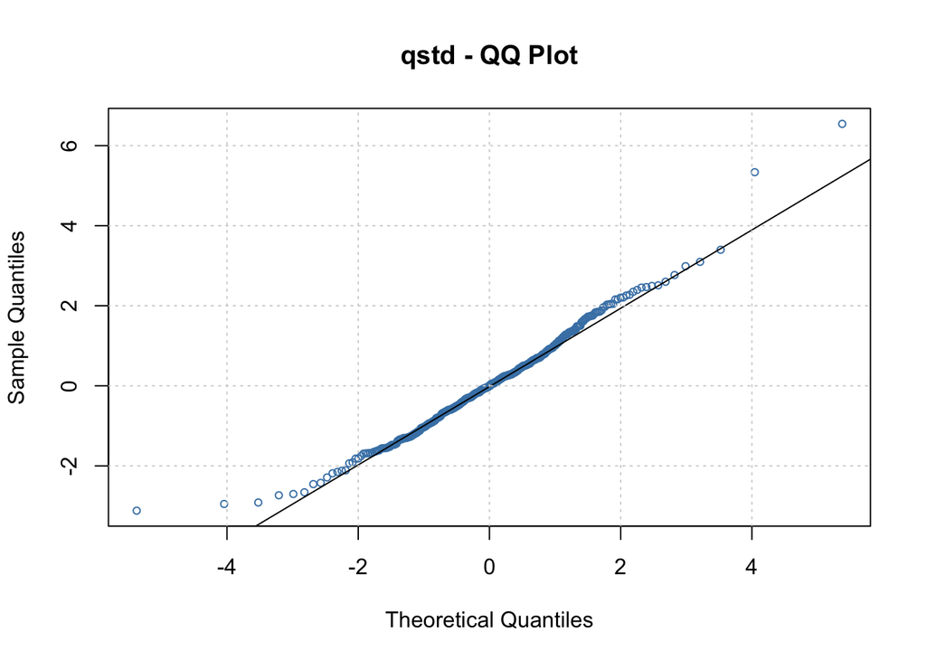

```
##
## Title:
##  GARCH Modelling
##
## Call:
##  garchFit(formula = ~1 + garch(1, 1), data = residuals, cond.dist = "sstd",
##     trace = FALSE)
##
## Mean and Variance Equation:
##  data ~ 1 + garch(1, 1)
## <environment: 0x12079ee88>
##  [data = residuals]
##
## Conditional Distribution:
##  sstd
##
## Coefficient(s):
##          mu        omega       alpha1        beta1         skew        shape
## -4.2910e-04   3.1266e-06   5.5406e-02   8.8877e-01   1.0565e+00   4.2870e+00
##
## Std. Errors:
##  based on Hessian
##
## Error Analysis:
##          Estimate  Std. Error  t value Pr(>|t|)
## mu     -4.291e-04   2.650e-04   -1.619    0.105
## omega   3.127e-06   2.843e-06    1.100    0.271
## alpha1  5.541e-02   3.415e-02    1.622    0.105
## beta1   8.888e-01   7.821e-02   11.364  < 2e-16 ***
## skew    1.056e+00   5.397e-02   19.577  < 2e-16 ***
## shape   4.287e+00   7.763e-01    5.522 3.34e-08 ***
## ---
## Signif. codes:  0 '***' 0.001 '**' 0.01 '*' 0.05 '.' 0.1 ' ' 1
##
## Log Likelihood:
##  2455.863    normalized:  3.585202
##
## Description:
##  Tue Feb 18 13:34:22 2025 by user:
##
##
## Standardised Residuals Tests:
##                                   Statistic      p-Value
##  Jarque-Bera Test   R    Chi^2  526.1384544 0.000000e+00
##  Shapiro-Wilk Test  R    W        0.9576365 3.765340e-13
##  Ljung-Box Test     R    Q(10)    4.9602153 8.938198e-01
##  Ljung-Box Test     R    Q(15)   14.9590001 4.543745e-01
##  Ljung-Box Test     R    Q(20)   17.5352219 6.179958e-01
##  Ljung-Box Test     R^2  Q(10)   10.2713595 4.170173e-01
##  Ljung-Box Test     R^2  Q(15)   11.5831252 7.102695e-01
##  Ljung-Box Test     R^2  Q(20)   19.8642709 4.664485e-01
##  LM Arch Test       R    TR^2    11.3696024 4.975371e-01
##
## Information Criterion Statistics:
##       AIC       BIC       SIC      HQIC
## -7.152886 -7.113212 -7.153038 -7.137534
```

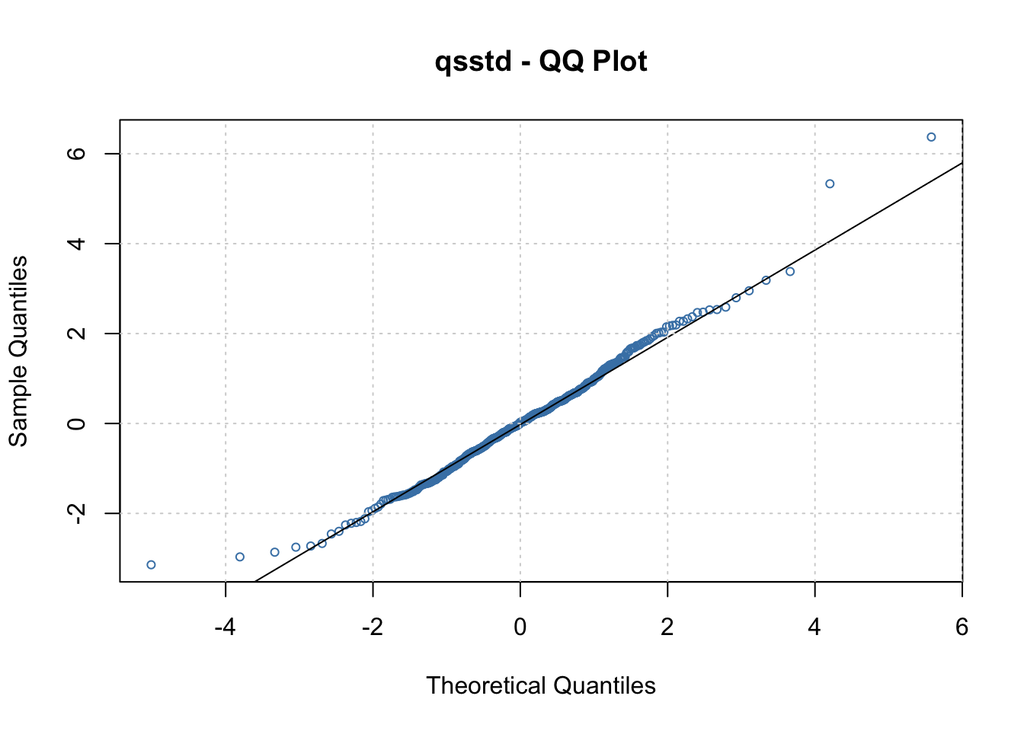

# Model Diagnosis

## ARIMA Diagnosis

### Inverse Roots of AR and MA Polynomials

[figure not shown]

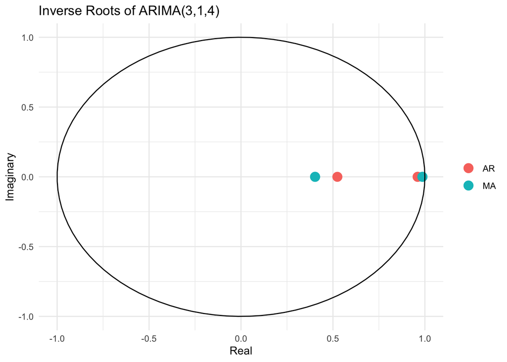

### Residual Diagnostics

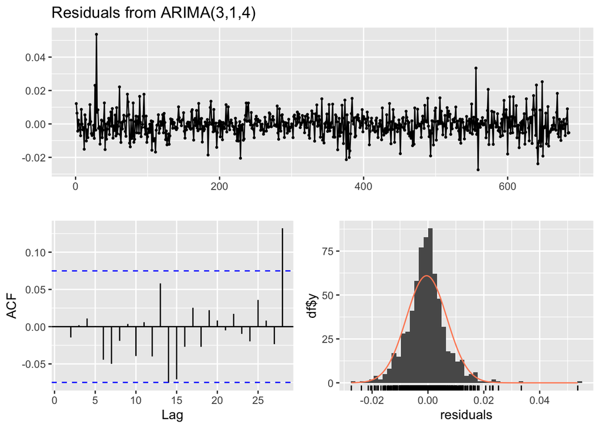

```
##
##  Ljung-Box test
##
## data:  Residuals from ARIMA(3,1,4)
## Q* = 4.6727, df = 3, p-value = 0.1974
##
## Model df: 7.   Total lags used: 10
```

1. The **Ljung-Box test** is used to check if residuals are independent.  
   The **p-value = 0.1974 is greater than 0.05**, meaning we **fail to reject the null hypothesis that residuals are white noise.**  
   This further confirms that the model has captured the time series structure well, and no significant autocorrelation remains.
2. The **top panel** shows residuals fluctuating randomly, indicating **no strong pattern** remains.

   The **ACF plot (bottom left)** shows residuals are **mostly uncorrelated**, meaning the model sufficiently explains the data.

   These indicate that the ARIMA(3,1,4) model fits well and that its residuals resemble **white noise**, making it a good candidate for forecasting.

## GARCH Diagnosis

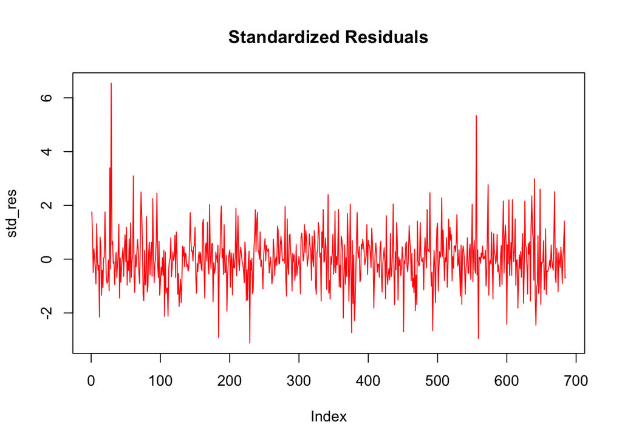

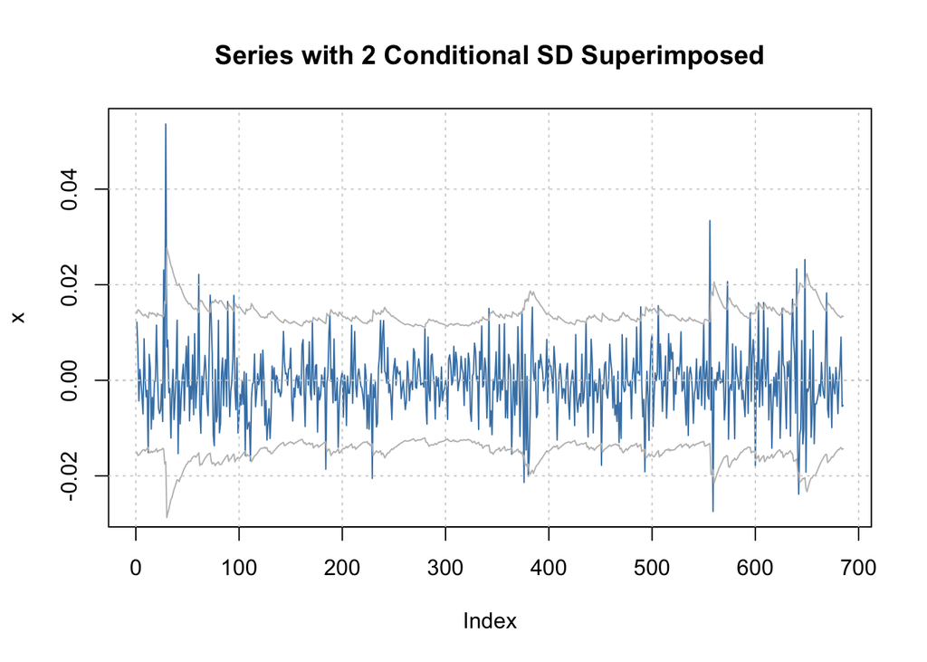

# Forecasting

## ARIMA

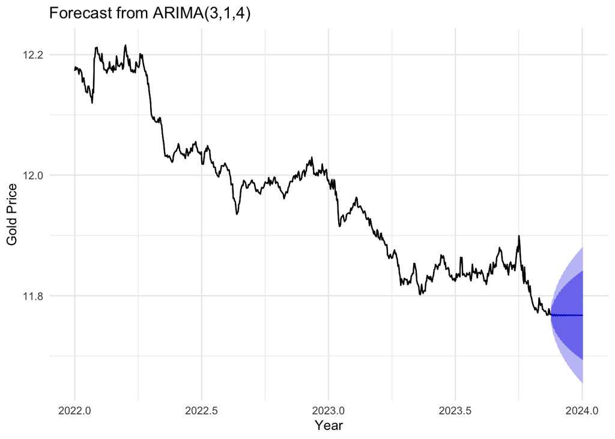

## GARCH

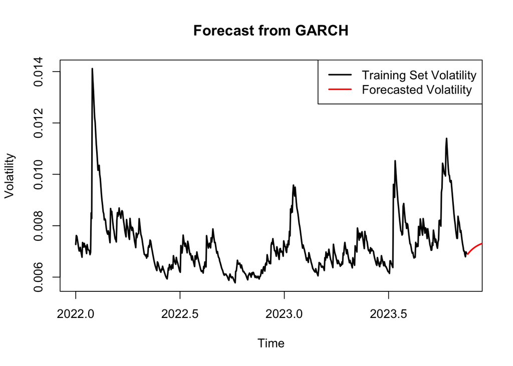

# Conclusion

The **ARIMA(3,1,4) model** effectively captures the **short-term trends** in gold prices, with forecasts aligning with recent movements. Residual diagnostics confirm that the model is **well-fitted**, and stability checks ensure **reliable predictions**. However, it did not account for volatility clustering, leading to potential underestimation of risk during turbulent periods.

## Limitations& Future Direction

Our models do not account for **external market factors**, and its long-term forecasting ability is limited. Future improvements could include **ARIMAX and machine learning models** to better capture volatility. A **hybrid ARIMA-GARCH approach** could improve accuracy by leveraging both mean and volatility dynamics for a more comprehensive forecast.

# References

1. Ionides, E. L. (2022). *Modeling and Analysis of Time Series Data: Chapter 8 - Smoothing in the time and frequency domains.* Retrieved from https://ionides.github.io/531w22/midterm_project/project22/blinded.html.
2. *Past Midterm Project - Project 10.* Retrieved from https://ionides.github.io/531w24/midterm_project/project10/blinded.html.
3. Chodavadiya, N. (2021). *Daily Gold Price (2015-2021) Time Series Dataset.* Retrieved from https://www.kaggle.com/datasets/nisargchodavadiya/daily-gold-price-20152021-time-series.
4. *Past Midterm Project - Project 22.* Retrieved from: [https://ionides.github.io/531w22/midterm_project/project22/blinded.html](https://ionides.github.io/531w22/midterm_project/project22/blinded.html#Diagnosis)
5. *Past* *Midterm Project - Project 14: ARMA-GARCH Model.* Retrieved from https://ionides.github.io/531w24/midterm_project/project14/blinded.html#arma-garch-model.
6. Peking University. (n.d.). *Financial Time Series - GARCH Model.* Retrieved from https://www.math.pku.edu.cn/teachers/lidf/course/fts/ftsnotes/html/_ftsnotes/fts-garch.html#garch-garch-model.
7. ChatGPT (2025). https://openai.com/chatgpt.